# Project: Identify Customer Segments

Below are the plots of the key PCA features for All data vs Data in Cluster 3

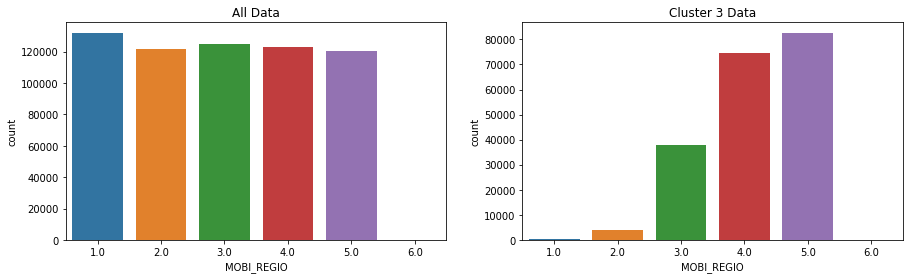

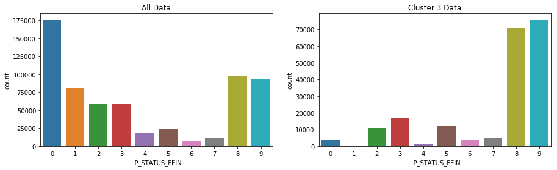

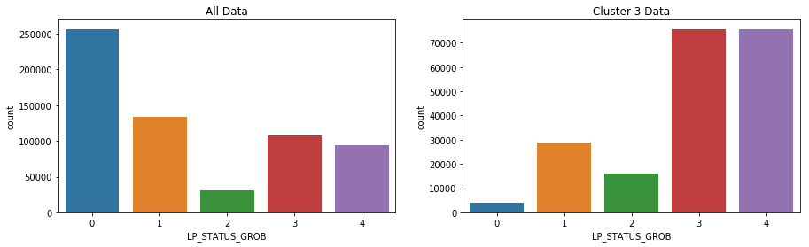

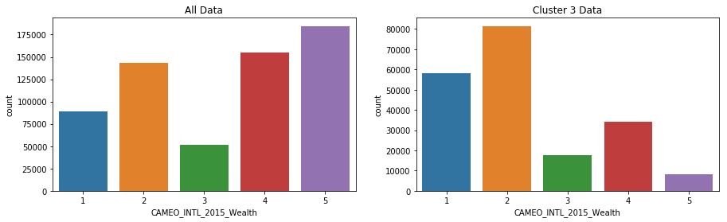

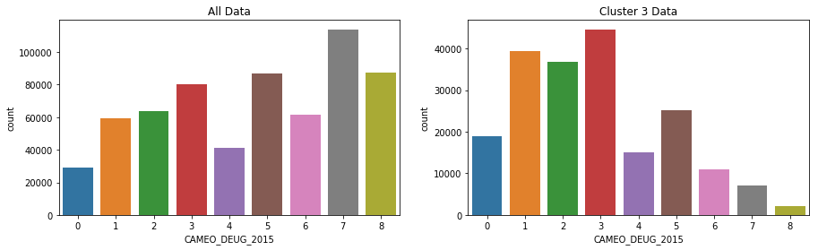

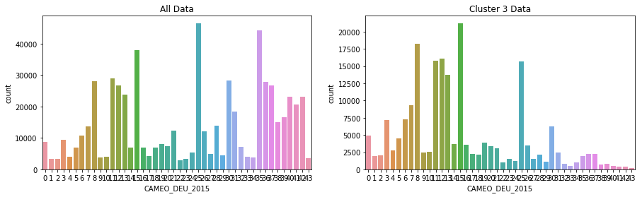

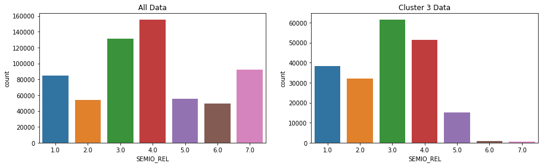

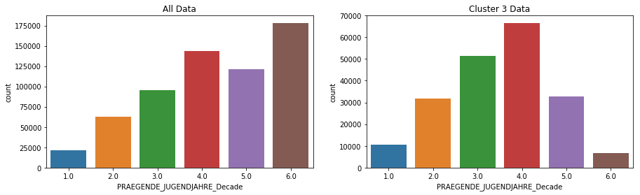

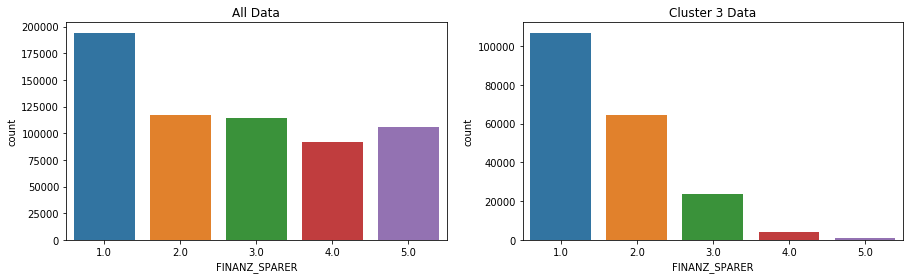

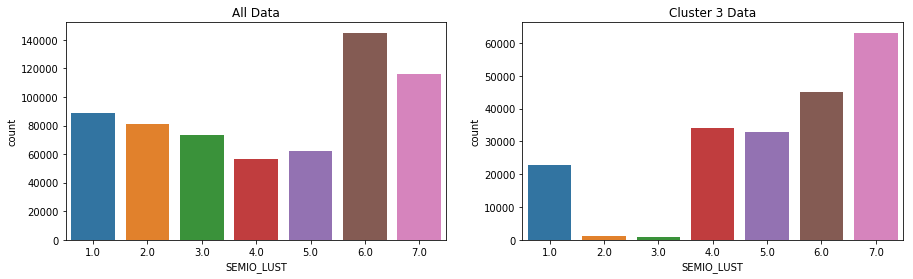

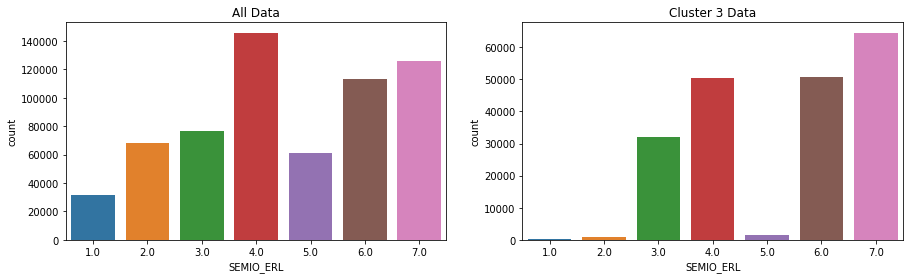

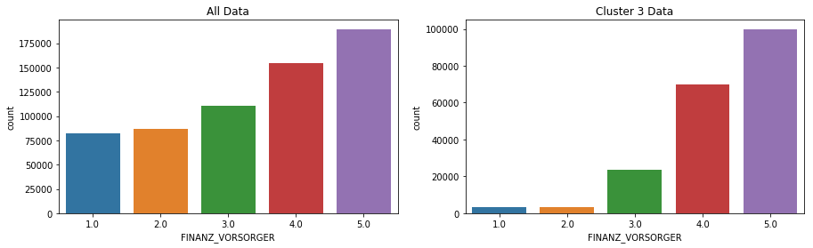

[7 more figures not shown]

```python
# Make a list of key features from PCA analysis in previous exercise
key_feats=['MOBI_REGIO','LP_STATUS_FEIN', 'LP_STATUS_GROB',
           'CAMEO_INTL_2015_Wealth', 'CAMEO_DEUG_2015', 'CAMEO_DEU_2015',
           'SEMIO_REL', 'PRAEGENDE_JUGENDJAHRE_Decade', 'FINANZ_SPARER',
           'SEMIO_LUST','SEMIO_ERL', 'FINANZ_VORSORGER', 'ALTERSKATEGORIE_GROB',
           'ANREDE_KZ', 'SEMIO_KAEM', 'SEMIO_DOM',
           'SEMIO_FAM', 'SEMIO_SOZ','SEMIO_VERT']

# Loop through the list of features and make plots for overall data and data in Cluster 3
for i in key_feats:
    fig, ax = plt.subplots(1,2, sharex=True,figsize=(15,4))

    sns.countplot(i,data=gd, ax=ax[0])
    sns.countplot(i,data=gd[gd['ClusterID']==3], ax=ax[1])

    ax[0].set_title('All Data')
    ax[1].set_title('Cluster 3 Data')
```

### Discussion 3.3: Compare Customer Data to Demographics Data

Yes, we were able to identify segments popular and unpopular with the mail-order company. Cluster 2 which was overrepresented is the popular segment with the company and should be its target audience, whereas cluster 3 is underrepresented and is the unpopular segment.

Popular segment generally comprises of consumption oriented middle class, brought up in 80/90s whereas unpopular segment comprises of top earners from wealthy households brought up in 60/70s and are high money-savers

###### #

> Congratulations on making it this far in the project! Before you finish, make sure to check through the entire notebook from top to bottom to make sure that your analysis follows a logical flow and all of your findings are documented in **Discussion** cells. Once you've checked over all of your work, you should export the notebook as an HTML document to submit for evaluation. You can do this from the menu, navigating to **File -> Download as -> HTML (.html)**. You will submit both that document and this notebook for your project submission.